```python
import pandas as pd
import matplotlib.pyplot as plt
from IPython.display import display, HTML
```

# Step 1: Data exploration

```python
df = pd.read_excel("Project_Creating a visual story with AI.xlsx")
df.head()
```

|  | Date | Product | Category | Region | Sales Rep | Quantity Sold | Unit Price | Discount | Shipping Cost | Customer Type | Marketing Channel | Payment Method | Customer Satisfaction | Total Sales |
| --- | --- | --- | --- | --- | --- | --- | --- | --- | --- | --- | --- | --- | --- | --- |
| 0 | 2023-04-30 | Product E | Home & Kitchen | South | Rep 2 | 47 | 63.42 | 0.17 | 17.03 | Existing | Search Ads | Card | 3 | 2491.040 |
| 1 | 2023-04-10 | Product B | Clothing | North | Rep 1 | 48 | 86.34 | 0.18 | 16.09 | New | Social Media | Card | 3 | 5121.645 |
| 2 | 2023-05-04 | Product D | Clothing | East | Rep 3 | 46 | 83.77 | 0.12 | 12.18 | Existing | Social Media | Card | 1 | 5104.785 |
| 3 | 2023-08-01 | Product C | Home & Kitchen | North | Rep 3 | 2 | 37.67 | 0.02 | 7.94 | New | Social Media | Card | 2 | 81.770 |
| 4 | 2023-02-06 | Product C | Clothing | West | Rep 4 | 35 | 94.19 | 0.05 | 9.98 | Existing | Direct | Cash | 3 | 4712.700 |

```python
# Key statistical metrics from the dataset
df.describe()
```

|  | Date | Quantity Sold | Unit Price | Discount | Shipping Cost | Customer Satisfaction | Total Sales |
| --- | --- | --- | --- | --- | --- | --- | --- |
| count | 365 | 365.000000 | 365.000000 | 365.000000 | 365.000000 | 365.000000 | 365.000000 |
| mean | 2023-07-01 19:47:30.410958848 | 25.145205 | 56.820932 | 0.098904 | 12.248740 | 2.435616 | 1505.200548 |
| min | 2023-01-01 00:00:00 | 1.000000 | 10.240000 | 0.000000 | 5.020000 | 1.000000 | 33.780000 |
| 25% | 2023-04-07 00:00:00 | 14.000000 | 35.920000 | 0.050000 | 8.210000 | 1.000000 | 553.360000 |
| 50% | 2023-06-22 00:00:00 | 25.000000 | 57.040000 | 0.100000 | 12.040000 | 2.000000 | 1244.360000 |
| 75% | 2023-10-08 00:00:00 | 37.000000 | 77.640000 | 0.150000 | 16.240000 | 3.000000 | 2147.890000 |
| max | 2023-12-31 00:00:00 | 49.000000 | 99.940000 | 0.200000 | 19.980000 | 4.000000 | 6976.095000 |
| std | NaN | 13.634687 | 25.699273 | 0.059146 | 4.466806 | 1.104109 | 1235.125560 |

```python
# Top 5 Sales Reps by Total Sales
top_sales_reps = df.groupby('Sales Rep')['Total Sales'].sum().sort_values(ascending=False).head(5)
print("Top 5 Sales Reps:\n", top_sales_reps)
```

```
Top 5 Sales Reps:
 Sales Rep
Rep 5    119570.610
Rep 3    116589.135
Rep 2    110098.065
Rep 1    103953.845
Rep 4     99186.545
Name: Total Sales, dtype: float64
```

```python
# Top 5 Regions by Total Sales
top_regions = df.groupby('Region')['Total Sales'].sum().sort_values(ascending=False).head(5)
print("Top 5 Regions:\n", top_regions)
```

```
Top 5 Regions:
 Region
East     143680.995
West     142896.965
South    142601.030
North    120219.210
Name: Total Sales, dtype: float64
```

```
Sales trend over time:
count     229.000000
mean     2399.118777
std      2025.925506
min        41.040000
25%       910.800000
50%      1793.260000
75%      3315.450000
max      9471.675000
Name: Total Sales, dtype: float64
Findings: There are patterns in total sales over time. Peaks or dips could indicate seasonal trends or external influences.
Questions: Are these fluctuations tied to specific marketing campaigns, holidays, or other events?
```

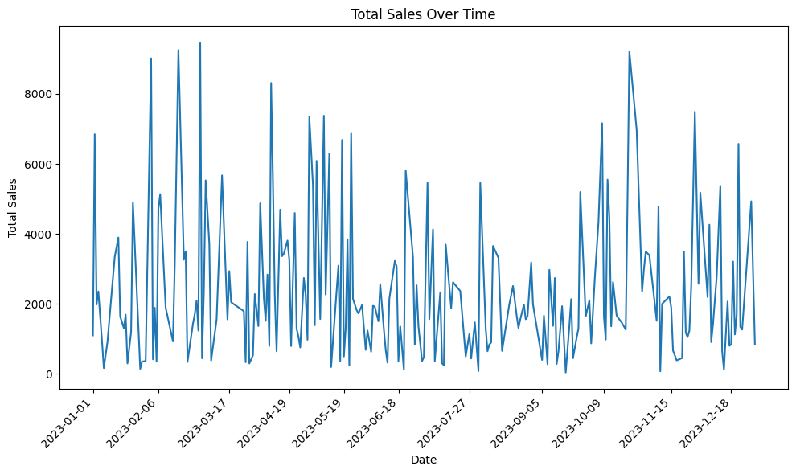

```python
# Sales trend
sales_trend = df.groupby('Date')['Total Sales'].sum()

# Display trend and findings
print("Sales trend over time:")
print(sales_trend.describe())
print("Findings: There are patterns in total sales over time. Peaks or dips could indicate seasonal trends or external influences.")
print("Questions: Are these fluctuations tied to specific marketing campaigns, holidays, or other events?")

# Visualization
plt.figure(figsize=(10, 6))
sales_trend.plot(title="Total Sales Over Time")
plt.xlabel("Date")
plt.ylabel("Total Sales")

# Add more x-axis ticks
plt.xticks(ticks=sales_trend.index[::max(1, len(sales_trend)//10)], rotation=45)

# Show the plot
plt.tight_layout()
plt.show()
```

```python
# Maximum total sales
max_sales_value = sales_trend.max()
# Date of maximum total sales
max_sales_date = sales_trend.idxmax()

# Print the results
print(f"The maximum total sales were {max_sales_value} on {max_sales_date}.")
```

```
The maximum total sales were 9471.675 on 2023-03-01 00:00:00.
```

```python
# Calculate shipping cost ratio
df['Shipping Cost Ratio'] = df['Shipping Cost'] / df['Total Sales']

# Identify outliers
outliers = df[df['Shipping Cost Ratio'] > 0.2]

# Display findings
print("Outliers in shipping costs:")
print(outliers[['Date', 'Region', 'Sales Rep', 'Shipping Cost', 'Total Sales']])
print(f"Findings: Found {len(outliers)} transactions where shipping costs are unusually high compared to total sales.")
print("Questions: Are these high shipping costs due to expedited shipping or errors in pricing? Is there a pattern across specific regions or customers?")
```

```
Outliers in shipping costs:
          Date Region Sales Rep  Shipping Cost  Total Sales
80  2023-05-21   West     Rep 3           7.78       33.780
147 2023-05-26   West     Rep 3          10.79       39.470
168 2023-09-18  South     Rep 2           9.44       41.040
211 2023-02-03  South     Rep 4          13.50       50.040
213 2023-07-17  South     Rep 5          12.17       59.390
241 2023-07-17   West     Rep 5          15.68       64.995
255 2023-04-11  South     Rep 5          19.32       63.970
287 2023-09-09   East     Rep 5          18.87       48.990
303 2023-04-02   East     Rep 4          18.45       59.750
Findings: Found 9 transactions where shipping costs are unusually high compared to total sales.
Questions: Are these high shipping costs due to expedited shipping or errors in pricing? Is there a pattern across specific regions or customers?
```

```python
# Product category with the highest total sales
# Group by product category and calculate total sales
category_sales = df.groupby('Category')['Total Sales'].sum()

# Find the category with the highest sales
top_category = category_sales.idxmax()
top_sales = category_sales.max()

# Display the results
print("Total sales by product category over the past year:")
print(category_sales)
print(f"\nThe product category with the highest total sales is '{top_category}' with a total of {top_sales}.")
```

```
Total sales by product category over the past year:
Category
Books              91888.53
Clothing          230700.45
Electronics       103997.60
Home & Kitchen    122811.62
Name: Total Sales, dtype: float64

The product category with the highest total sales is 'Clothing' with a total of 230700.45.
```

```python
# Marketing Channel most effective for new customer acquisitions
# Filter for new customers
new_customers = df[df['Customer Type'] == 'New']

# Group by marketing channel and count new customers
channel_effectiveness = new_customers.groupby('Marketing Channel').size().sort_values(ascending=False)

# Find the most effective marketing channel
most_effective_channel = channel_effectiveness.idxmax()
most_customers_acquired = channel_effectiveness.max()

# Display the results
print("New customers acquired by marketing channel:")
print(channel_effectiveness)
print(f"\nThe most effective marketing channel is '{most_effective_channel}', which acquired {most_customers_acquired} new customers.")
```

```
New customers acquired by marketing channel:
Marketing Channel
Social Media    190
dtype: int64

The most effective marketing channel is 'Social Media', which acquired 190 new customers.
```

# Step 2: Visualization creation

Enter the following prompt into Copilot online:

I want to create a dashboard to display key performance indicators (KPIs) from my sales data, which includes the following columns:

Date, Product Category, Region, Sales Rep, Quantity Sold, Unit Price, Discount, Shipping Cost, Customer Type, Marketing Channel, Payment Method, Customer Satisfaction, Total Sales

This dashboard will be presented to the marketing team. Could you suggest 6 KPIs to display on the dashboard that will provide valuable insights for the marketing team? One the KPIs should display the correlation between discounts applied and customer satisfaction ratings.

Additionally, please show me the code to create the dashboard using Python, Plotly and Dash.

### Copy and paste the code provided by Copilot online:

```python
# Total Sales
total_sales = df['Total Sales'].sum()

# Quantity Sold
quantity_sold = df['Quantity Sold'].sum()

# Average Order Value (AOV)
df['Order Value'] = df['Total Sales'] / df['Quantity Sold']
average_order_value = df['Order Value'].mean()

# Sales by Region
sales_by_region = df.groupby('Region')['Total Sales'].sum().reset_index()

# Sales by Marketing Channel
sales_by_channel = df.groupby('Marketing Channel')['Total Sales'].sum().reset_index()

# Correlation between Discounts and Customer Satisfaction
correlation = df[['Discount', 'Customer Satisfaction']].corr().iloc[0, 1]
```

Sales Dashboard

Total Sales

$549,398.20

Quantity Sold

9,178 units

Average Order Value (AOV)

$59.58

Discount vs. Customer Satisfaction

Correlation: 0.04

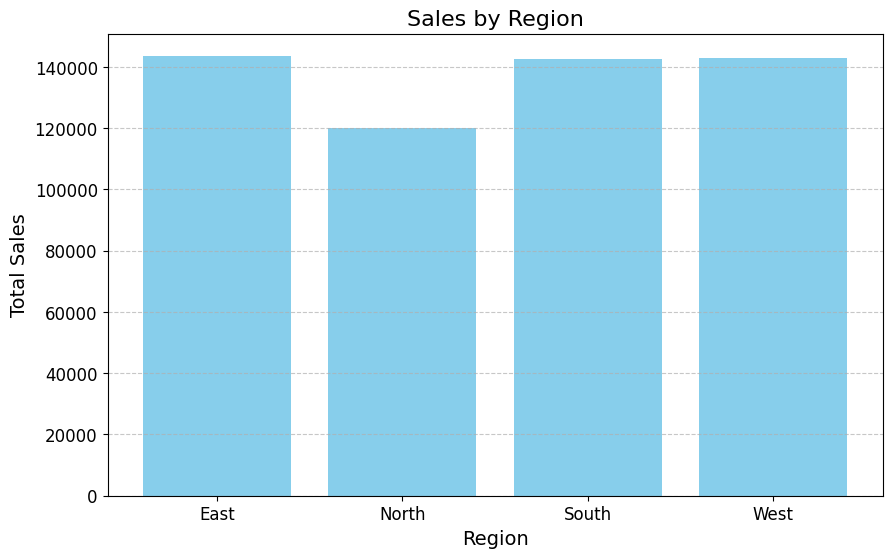

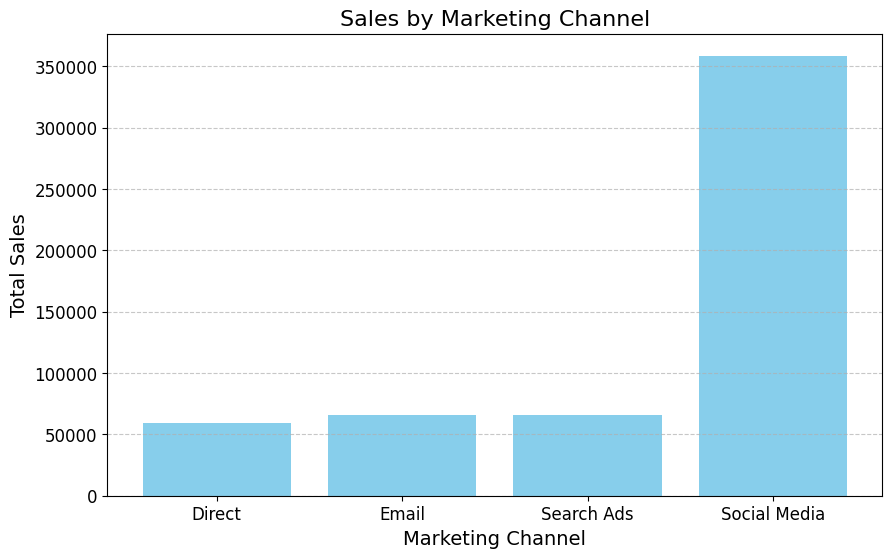

```python
# Display the metrics
display(HTML(f"""
    <div style="text-align: left; padding-left: 20px; margin-bottom: 30px;">
        <h1>Sales Dashboard</h1>
        <h2>Total Sales</h2>
        <h3>${total_sales:,.2f}</h3>
        <h2>Quantity Sold</h2>
        <h3>{quantity_sold:,} units</h3>
        <h2>Average Order Value (AOV)</h2>
        <h3>${average_order_value:,.2f}</h3>
        <h2>Discount vs. Customer Satisfaction</h2>
        <h3>Correlation: {correlation:.2f}</h3>
    </div>
"""))

# Create the Sales by Region chart
plt.figure(figsize=(10, 6))
plt.bar(sales_by_region['Region'], sales_by_region['Total Sales'], color='skyblue')
plt.title('Sales by Region', fontsize=16)
plt.xlabel('Region', fontsize=14)
plt.ylabel('Total Sales', fontsize=14)
plt.xticks(fontsize=12)
plt.yticks(fontsize=12)
plt.grid(axis='y', linestyle='--', alpha=0.7)
plt.show()

# Create and center the Sales by Marketing Channel chart
plt.figure(figsize=(10, 6))
plt.bar(sales_by_channel['Marketing Channel'], sales_by_channel['Total Sales'], color='skyblue')
plt.title('Sales by Marketing Channel', fontsize=16)
plt.xlabel('Marketing Channel', fontsize=14)
plt.ylabel('Total Sales', fontsize=14)
plt.xticks(fontsize=12)
plt.yticks(fontsize=12)
plt.grid(axis='y', linestyle='--', alpha=0.7)
plt.show()
```

# Step 3: Automated report creation

Enter the following prompt into Copilot online:

Improve the dashboard code to include a feature that generates a report summarizing key findings and insights from the sales data. The report should be well-written and formatted for presentation to the Marketing team.

### Copy and paste the code provided by Copilot online:

```python
def generate_report():

    report = f"""

    Total Sales: ${total_sales:,.2f}


    Quantity Sold: {quantity_sold:,} units


    Average Order Value (AOV): ${average_order_value:,.2f}


    Key Insights:

    - Sales by Region: The region with the highest sales is {sales_by_region.loc[sales_by_region['Total Sales'].idxmax(), 'Region']} with total sales of ${sales_by_region['Total Sales'].max():,.2f}.

    - Sales by Marketing Channel: The most effective marketing channel is {sales_by_channel.loc[sales_by_channel['Total Sales'].idxmax(), 'Marketing Channel']} with total sales of ${sales_by_channel['Total Sales'].max():,.2f}.

    - Correlation between Discounts and Customer Satisfaction:

      The correlation coefficient between discounts and customer satisfaction is {correlation:.2f}.
    """

    return report
```

Sales Dashboard

Total Sales

$549,398.20

Quantity Sold

9,178 units

Average Order Value (AOV)

$59.58

Discount vs. Customer Satisfaction

Correlation: 0.04

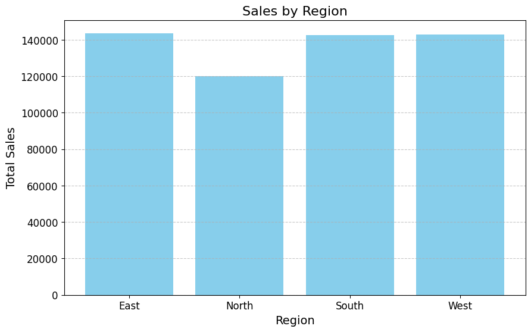

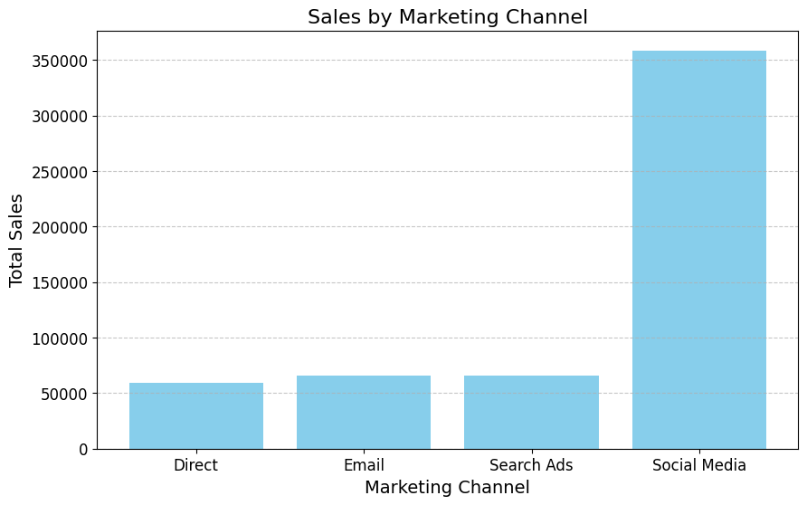

Sales Report Summary

```
    Total Sales: $549,398.20


    Quantity Sold: 9,178 units


    Average Order Value (AOV): $59.58


    Key Insights:

    - Sales by Region: The region with the highest sales is East with total sales of $143,680.99.

    - Sales by Marketing Channel: The most effective marketing channel is Social Media with total sales of $358,604.77.

    - Correlation between Discounts and Customer Satisfaction:

      The correlation coefficient between discounts and customer satisfaction is 0.04.
```

```python
# Create HTML content for the text
dashboard_text = """
<h1 style="text-align:left; padding-left: 20px;">Sales Dashboard</h1>
<div style="text-align:left; padding-left: 20px;">
    <h2>Total Sales</h2>
    <h3>${:,.2f}</h3>

    <h2>Quantity Sold</h2>
    <h3>{:,} units</h3>

    <h2>Average Order Value (AOV)</h2>
    <h3>${:,.2f}</h3>

    <h2>Discount vs. Customer Satisfaction</h2>
    <h3>Correlation: {:.2f}</h3>
</div>
""".format(total_sales, quantity_sold, average_order_value, correlation)

# Display the text
display(HTML(dashboard_text))

# Create the Sales by Region chart
plt.figure(figsize=(10, 6))
plt.bar(sales_by_region['Region'], sales_by_region['Total Sales'], color='skyblue')
plt.title('Sales by Region', fontsize=16)
plt.xlabel('Region', fontsize=14)
plt.ylabel('Total Sales', fontsize=14)
plt.xticks(fontsize=12)
plt.yticks(fontsize=12)
plt.grid(axis='y', linestyle='--', alpha=0.7)
plt.show()

# Create and center the Sales by Marketing Channel chart
plt.figure(figsize=(10, 6))
plt.bar(sales_by_channel['Marketing Channel'], sales_by_channel['Total Sales'], color='skyblue')
plt.title('Sales by Marketing Channel', fontsize=16)
plt.xlabel('Marketing Channel', fontsize=14)
plt.ylabel('Total Sales', fontsize=14)
plt.xticks(fontsize=12)
plt.yticks(fontsize=12)
plt.grid(axis='y', linestyle='--', alpha=0.7)
plt.show()


# Generate and display the report
report = generate_report()

# Display the report text in the dashboard
report_text = f"""
<div style="padding: 20px; border: 1px solid black; margin-top: 20px;">
    <h3>Sales Report Summary</h3>
    <pre>{report}</pre>
</div>
"""

# Display the report
display(HTML(report_text))
```

# Step 4: Feedback and refinement

To request feedback and refine the dashboard, you can follow these suggestions:

**1. Share the dashboard and report:**

- Distribute the dashboard and report to stakeholders through their preferred platform (email, cloud storage, or collaboration tools).
- Include a brief introduction explaining the purpose and key findings.

**2. Request feedback:**

- Ask stakeholders for specific feedback on content (Are the KPIs relevant? Are any insights missing?), design (Is the layout user-friendly?), and functionality (Are there any issues with navigation or interactivity?).
- Encourage them to highlight any questions or concerns.

**3. Collect and organize feedback:**

- Gather feedback through surveys, forms, or direct communication.
- Summarize the feedback into actionable themes, prioritizing content, design, and functionality.

**4. Refine the dashboard and report:**

- Content: Adjust KPIs and insights based on input (e.g., add metrics or clarify data).
- Design: Improve layout and visuals for clarity and ease of use.
- Functionality: Address technical issues and improve interactivity where needed.

**5. Share the updated version:**

- Distribute the revised dashboard and report to stakeholders, noting the changes made based on their feedback.

**6. Iterate continuously:**

- Regularly seek feedback to keep improving the dashboard and report, ensuring they meet stakeholder needs.

By following these steps, you’ll ensure the dashboard and report meet stakeholder expectations and drive more effective business decisions.